# STAT 240 Discussion 6

## Create Data Frames

Make data frames that also have an index variable which is the row number.

```r
df_words = tibble(
  index = seq_along(stringr::words),
  words = stringr::words)

df_colors = tibble(
  index = seq_along(colors()),
  colors = colors())
```

### 1

> Find the lengths of all strings in `df_words` and make a histogram that shows the number of words for each length. Use wise choices for the boundary and binwidth. *(Hint: use `mutate()` to add a column to `df_words` and use `str_length()` to calculate the value to put into this column.)*

> After making a histogram, make a bar chart with the same information. Which do you prefer and why?

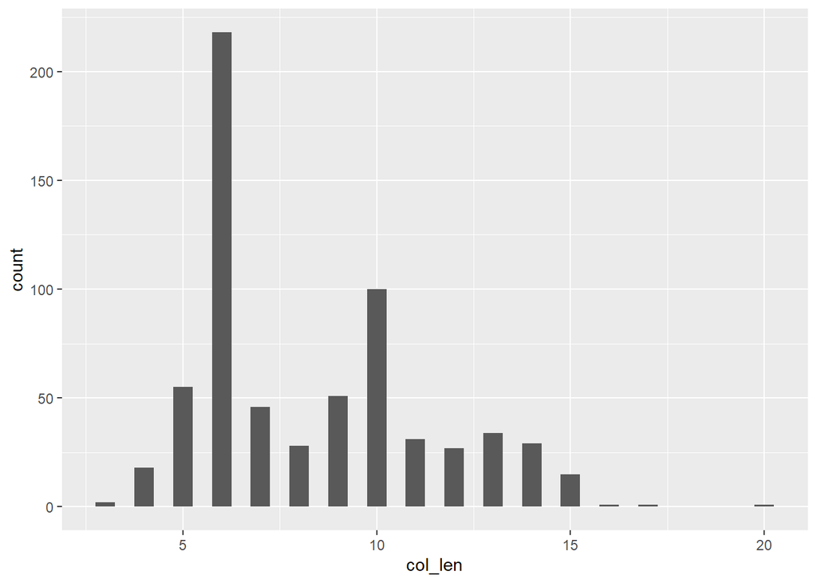

```r
color_length <- df_colors %>%
    mutate(col_len = str_length(colors)) %>%
    arrange(col_len) %>%
    group_by(col_len)

ggplot(color_length, aes(x=col_len)) +
geom_histogram(binwidth=0.5)
```

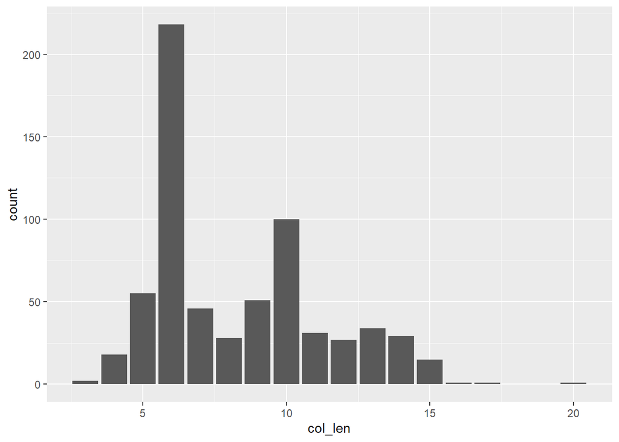

```r
ggplot(color_length, aes(x=col_len)) +
geom_bar()
```

### 2

> The R command `colors()` returns an array with all of the color names that R knows about. Filter to find all colors that contain the pattern “red”. *(Hint: use `str_detect()`.)*. Report the number of colors and the first and last of these alphabetically.

```r
red_colors <- df_colors %>%
  filter(str_detect(colors, "red"))

red_colors %>%
  summarize(n=n(), first=min(colors), last=max(colors))
```

```
## # A tibble: 1 x 3
##       n first   last
##   <int> <chr>   <chr>
## 1    27 darkred violetred4
```

### Response

- Total 27 Colors that contain the pattern “red”.
- This data starts with “darkred” and ends with “violetred4”.

### 3

> How many words in `df_words` begin with each letter? Do not distinguish between lower case and capital letters. Make a bar graph that displays these counts. Then repeat for the last letter of each word. *(Hint: use `mutate()` and `str_sub()` to create new columns with the first and last letter of each word and then make the graphs. Use either `str_to_lower()` or `str_to_upper()` to before counting.)*

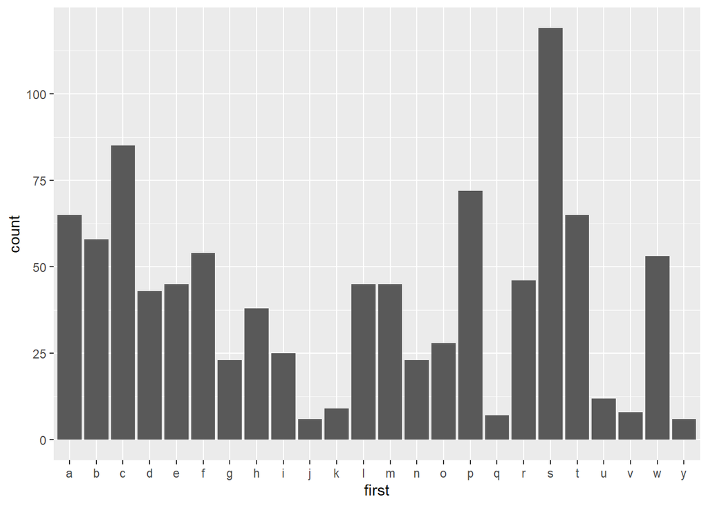

```r
start_first <- df_words %>%
  mutate( first= str_to_lower(str_sub(words,1,1)) ) %>%
  group_by(first)

end_last <- df_words %>%
  mutate( last= str_to_lower(str_sub(words,-1,-1)) ) %>%
  group_by(last)

ggplot(start_first, aes(x=first) ) +
  geom_bar()
```

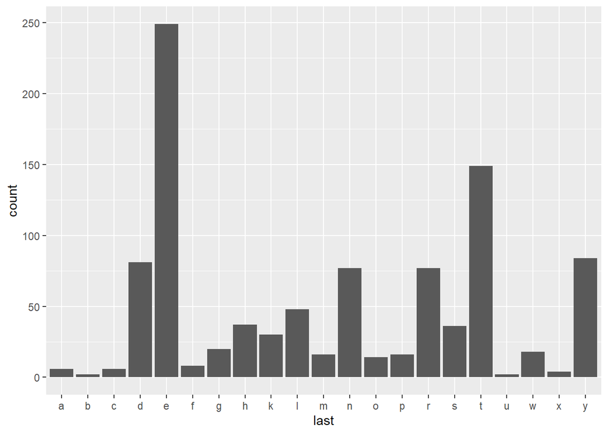

```r
ggplot(end_last, aes(x=last)) +
  geom_bar()
```

### 4

> Find all words in `df_words` that begin and end with the most popular letter (regardless of capitalization) for each position. Report the number of such words and the first and last in alphabetical order. *(Hint: Use `filter()` with `str_detect()` and a regular expression to identify the words. Then use `summarize()` to answer the questions.)*

```r
popular_first<- df_words %>%
  filter(str_to_lower(str_sub(words,1,1)) == 's') %>%
  summarize(n=n(), first=min(words), last=max(words))

popular_first
```

```
## # A tibble: 1 x 3
##       n first last
##   <int> <chr> <chr>
## 1   119 safe  system
```

### Response

- Total 119 words that starts with most popular letter ‘s’.
- The first appearing word is ‘safe’ and the last counterpart is ‘system’.

### 5

> Find and display all words in `df_words` that begin with a capital letter. Then, write them with that letter replaced by a lower case letter. How many such words are there? *(Hint: Use `filter()` and `str_detect()` with a regular expression involving `^[:upper:]`) to find the words and `str_c()`, `str_to_lower()` and `str_sub()` inside of `mutate()` to solve the problem.)*

```r
upper_words <- df_words %>%
  filter(str_detect(words, '^[:upper:]'))

upper_words$words <-
  str_to_lower(upper_words$words)

upper_words
```

```
## # A tibble: 2 x 2
##   index words
##   <int> <chr>
## 1   150 christ
## 2   151 christmas
```

### 6

> Create a string named `color_string` which has all of the colors in `df_colors()` that do not contain digits separated by the symbol `|` arranged alphabetically. How many such colors are there? Display the first 30 characters of `color_string`. *(Hint: Use `str_detect()` and `[:digit:]` to `filter()` the appropriate rows, `pull()` to extract a column as a vector, and `str_c()` with argument `collapse` set appropriately.)*

```r
color_string <- df_colors %>%
    filter(str_detect(colors, '|')) %>%
    arrange(colors)

color_string %>%
  summarize(n=n())
```

```
## # A tibble: 1 x 1
##       n
##   <int>
## 1   657
```

```r
head(color_string, 30)
```

```
## # A tibble: 30 x 2
##    index colors
##    <int> <chr>
##  1     2 aliceblue
##  2     3 antiquewhite
##  3     4 antiquewhite1
##  4     5 antiquewhite2
##  5     6 antiquewhite3
##  6     7 antiquewhite4
##  7     8 aquamarine
##  8     9 aquamarine1
##  9    10 aquamarine2
## 10    11 aquamarine3
## # ... with 20 more rows
```

### 7

> Find all words in `df_words` that match a color in `color_string` exactly. Display the list. How many such words are there? *(Hint: Use `str_match()` inside of `mutate()` to create a column named `match` which saves the pattern where `words` matches `color_string`, drop missing values, and then `filter()` to keep only those cases where there is an exact match between the word and the matching pattern.)*

```r
df_words %>%
  mutate( match = str_match(words, color_string$colors) ) %>%
  drop_na()
```

```
## # A tibble: 0 x 3
## # ... with 3 variables: index <int>, words <chr>, match[,1] <chr>
```